# Lab3

**Dragos Ailoae**

Applied Statistics and Econometrics 2

2022-02-10

## Intro to Panel Data Analysis with R

## The SUR Model

To illustrate the basics of SUR analysis with R we will use a subset of the Grunfeld data set, used by Arnold Zellner in his classic 1962 paper on seemingly unrelated regressions. Grunfeld originally used the dataset in his 1958 PhD thesis *The determinants of corporate investment.* at the University of Chicago.

Our dataset includes two firms, US (US Steel) and DM (Diamond Match) observed over the period 1935 to 1954. The problem is to find the determinants of investment by a firm, $i n v_{i t}$ among regressors such as the value of the firm, $v_{i t}$, and capital stock $k_{i t}$.

The Grunfeld Investment model is as follows: $$ inv_{i t}=\beta_{0 i}+\beta_{1 i} v_{i t}+\beta_{2 i} k_{i t}+\epsilon_{i t} $$

where

$\begin{aligned} {inv}_{{i t}}&= \text {gross investment for firm } {i} \text { at time } {t} \\ {v}_{{i t}}&=\text { market value of firm } {i} \text { at } {t} \\ {k}_{{i t}} &=\text { capital stock of firm } {i} \text { at } {t} . \end{aligned}$

Let's begin by loading some necessary packages and the dataset:

```r
rm(list=ls())    # Removes all items in Environment!
options(repr.plot.width = 5, repr.plot.height = 5)
# LOAD PACKAGES:
packages <- c("plm","systemfit","modelsummary")
# Loop though vector and load respective packages:
zzz <- lapply(packages, function(xxx) suppressMessages(require(xxx,
               character.only = TRUE, quietly=TRUE, warn.conflicts = FALSE)))  # quiet no warnings
#zzz <- lapply(packages, require, character.only = TRUE) # verbose with warnings
```

```r
my.raw.data <- read.csv(url("https://www747.github.io/NYU1102/Lab3/grun_data.csv"))
my.raw.data
```

| firm | year | inv | val | cap |
| --- | --- | --- | --- | --- |
| US | 1935 | 209.90 | 1362.40 | 53.80 |
| US | 1936 | 355.30 | 1807.10 | 50.50 |
| US | 1937 | 469.90 | 2676.30 | 118.10 |
| US | 1938 | 262.30 | 1801.90 | 260.20 |
| US | 1939 | 230.40 | 1957.30 | 312.70 |
| US | 1940 | 361.60 | 2202.90 | 254.20 |
| US | 1941 | 472.80 | 2380.50 | 261.40 |
| US | 1942 | 445.60 | 2168.60 | 298.70 |
| US | 1943 | 361.60 | 1985.10 | 301.80 |
| US | 1944 | 288.20 | 1813.90 | 279.10 |
| US | 1945 | 258.70 | 1850.20 | 213.80 |
| US | 1946 | 420.30 | 2067.70 | 132.60 |
| US | 1947 | 420.50 | 1796.70 | 264.80 |
| US | 1948 | 494.50 | 1625.80 | 306.90 |
| US | 1949 | 405.10 | 1667.00 | 351.10 |
| US | 1950 | 418.80 | 1677.40 | 357.80 |
| US | 1951 | 588.20 | 2289.50 | 342.10 |
| US | 1952 | 645.50 | 2159.40 | 444.20 |
| US | 1953 | 641.00 | 2031.30 | 623.60 |
| US | 1954 | 459.30 | 2115.50 | 669.70 |
| DM | 1935 | 2.54 | 70.91 | 4.50 |
| DM | 1936 | 2.00 | 87.94 | 4.71 |
| DM | 1937 | 2.19 | 82.20 | 4.57 |
| DM | 1938 | 1.99 | 58.72 | 4.56 |
| DM | 1939 | 2.03 | 80.54 | 4.38 |
| DM | 1940 | 1.81 | 86.47 | 4.21 |
| DM | 1941 | 2.14 | 77.68 | 4.12 |
| DM | 1942 | 1.86 | 62.16 | 3.83 |
| DM | 1943 | 0.93 | 62.24 | 3.58 |
| DM | 1944 | 1.18 | 61.82 | 3.41 |
| DM | 1945 | 1.36 | 65.85 | 3.31 |
| DM | 1946 | 2.24 | 69.54 | 3.23 |
| DM | 1947 | 3.81 | 64.97 | 3.90 |
| DM | 1948 | 5.66 | 68.00 | 5.38 |
| DM | 1949 | 4.21 | 71.24 | 7.39 |
| DM | 1950 | 3.42 | 69.05 | 8.74 |
| DM | 1951 | 4.67 | 83.04 | 9.07 |
| DM | 1952 | 6.00 | 74.42 | 9.93 |
| DM | 1953 | 6.53 | 63.51 | 11.68 |
| DM | 1954 | 5.12 | 58.12 | 14.33 |

As a first step, we may want to fit the data for each firm using our old friend the lm() function. So let's break up the dataset into two separate subsets, one for DM and another for US.

```r
US.data <- subset(my.raw.data,firm=="US")
head(US.data)
DM.data <- subset(my.raw.data,firm=="DM")
head(DM.data)
```

| firm | year | inv | val | cap |
| --- | --- | --- | --- | --- |
| US | 1935 | 209.9 | 1362.4 | 53.8 |
| US | 1936 | 355.3 | 1807.1 | 50.5 |
| US | 1937 | 469.9 | 2676.3 | 118.1 |
| US | 1938 | 262.3 | 1801.9 | 260.2 |
| US | 1939 | 230.4 | 1957.3 | 312.7 |
| US | 1940 | 361.6 | 2202.9 | 254.2 |

|  | firm | year | inv | val | cap |
| --- | --- | --- | --- | --- | --- |
| 21 | DM | 1935 | 2.54 | 70.91 | 4.50 |
| 22 | DM | 1936 | 2.00 | 87.94 | 4.71 |
| 23 | DM | 1937 | 2.19 | 82.20 | 4.57 |
| 24 | DM | 1938 | 1.99 | 58.72 | 4.56 |
| 25 | DM | 1939 | 2.03 | 80.54 | 4.38 |
| 26 | DM | 1940 | 1.81 | 86.47 | 4.21 |

We can now fit the US data using lm():

```r
lm.US <- lm(inv ~ val + cap, US.data)
summary(lm.US)
```

```
Call:
lm(formula = inv ~ val + cap, data = US.data)

Residuals:
     Min       1Q   Median       3Q      Max
-184.488  -77.210    4.508   59.421  144.035

Coefficients:
            Estimate Std. Error t value Pr(>|t|)
(Intercept) -49.1983   148.0754  -0.332   0.7438
val           0.1749     0.0742   2.357   0.0307 *
cap           0.3896     0.1424   2.737   0.0140 *
---
Signif. codes:  0 '***' 0.001 '**' 0.01 '*' 0.05 '.' 0.1 ' ' 1

Residual standard error: 96.43 on 17 degrees of freedom
Multiple R-squared:  0.4709,	Adjusted R-squared:  0.4086
F-statistic: 7.564 on 2 and 17 DF,  p-value: 0.00447
```

And similarly for DM:

```r
lm.DM <- lm(inv ~ val + cap, DM.data)
summary(lm.DM)
```

```
Call:
lm(formula = inv ~ val + cap, data = DM.data)

Residuals:
    Min      1Q  Median      3Q     Max
-1.5748 -0.5972 -0.3036  0.3834  2.8344

Coefficients:
            Estimate Std. Error t value Pr(>|t|)
(Intercept) 0.161519   2.065564   0.078    0.939
val         0.004573   0.027161   0.168    0.868
cap         0.437369   0.079589   5.495 3.94e-05 ***
---
Signif. codes:  0 '***' 0.001 '**' 0.01 '*' 0.05 '.' 0.1 ' ' 1

Residual standard error: 1.085 on 17 degrees of freedom
Multiple R-squared:  0.6432,	Adjusted R-squared:  0.6012
F-statistic: 15.32 on 2 and 17 DF,  p-value: 0.0001571
```

We may suspect that idiosyncratic macroeconomic shocks may have affected both firms. Consequently, there may be contemporaneous correlations in our disturbances that can be exploited to improve the efficiency of our OLS estimators.

Assuming the OLS estimation is unbiased, the residuals may be a good indicator of the economic disturbances so we may want to inspect visually if the two sets of residuals show similar patterns:

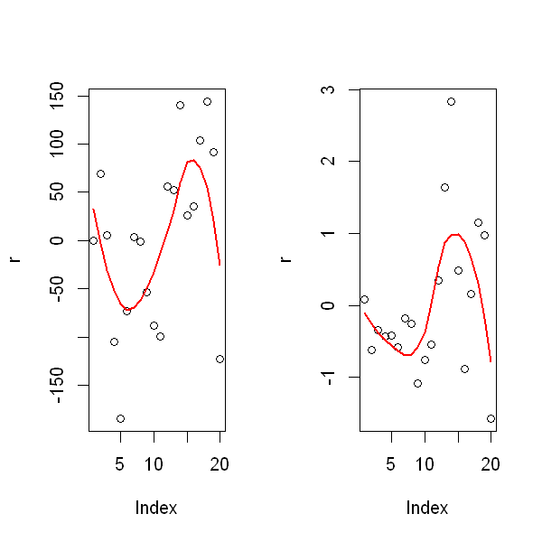

```r
par(mfrow = c(1, 2))

r <- lm.US$res
n<- 1:length(r)
plot(r)
lines(predict(loess(r~n)), col='red', lwd=2)

r <- lm.DM$res
n<- 1:length(r)
plot(r)
lines(predict(loess(r~n)), col='red', lwd=2)
```

The trend of the residuals appear correlated so we may consider using a panel model to improve the efficiency of our estimators.

Two R packages frequently used for panel data analysis are PLM and SYSTEMFIT. To use the functions in these packages we must first configure our data as a panel object by specifying the columns containing the i and t indexing:

```r
my.data <- pdata.frame(my.raw.data, c("firm", "year"))  #configure the data as a panel
head(my.data)
```

|  | firm | year | inv | val | cap |
| --- | --- | --- | --- | --- | --- |
| DM-1935 | DM | 1935 | 2.54 | 70.91 | 4.50 |
| DM-1936 | DM | 1936 | 2.00 | 87.94 | 4.71 |
| DM-1937 | DM | 1937 | 2.19 | 82.20 | 4.57 |
| DM-1938 | DM | 1938 | 1.99 | 58.72 | 4.56 |
| DM-1939 | DM | 1939 | 2.03 | 80.54 | 4.38 |
| DM-1940 | DM | 1940 | 1.81 | 86.47 | 4.21 |

Functions in these packages allow us to do equation by equation OLS estimation directly without having to split our data. For example, using pvcm() in the PLM package:

```r
myOLS.pvcm <- pvcm(inv ~ val + cap, data=my.data, model="within")
myOLS.pvcm
```

```
Model Formula: inv ~ val + cap
<environment: 0x000000000a5ea158>

Coefficients:
   (Intercept)       val     cap
DM     0.16152 0.0045734 0.43737
US   -49.19832 0.1748560 0.38964
```

Or systemfit() in the SYSTEMFIT package:

```r
myOLS.sysfit <- systemfit(inv ~ val+cap, "OLS", data=my.data)
#summary(myOLS.sysfit)
get_estimates(myOLS.sysfit)
```

| term | estimate | std.error | statistic | p.value | conf.low | conf.high |
| --- | --- | --- | --- | --- | --- | --- |
| DM_(Intercept) | 0.161518567 | 2.06556414 | 0.07819586 | 9.385853e-01 | -4.19644084 | 4.51947797 |
| DM_val | 0.004573432 | 0.02716079 | 0.16838365 | 8.682686e-01 | -0.05273082 | 0.06187768 |
| DM_cap | 0.437369190 | 0.07958891 | 5.49535372 | 3.940826e-05 | 0.26945128 | 0.60528710 |
| US_(Intercept) | -49.198321862 | 148.07536507 | -0.33225190 | 7.437606e-01 | -361.61003378 | 263.21339006 |
| US_val | 0.174856015 | 0.07419805 | 2.35661209 | 3.069905e-02 | 0.01831182 | 0.33140021 |
| US_cap | 0.389641889 | 0.14236688 | 2.73688583 | 1.404874e-02 | 0.08927403 | 0.69000974 |

The systemfit() output object allows us to quickly look at the contemporaneous covariance and correlation matrices:

```r
summary(myOLS.sysfit)$residCov
```

|  | DM | US |
| --- | --- | --- |
| DM | 1.178043 | 73.45838 |
| US | 73.458384 | 9299.60405 |

```r
summary(myOLS.sysfit)$residCor
```

|  | DM | US |
| --- | --- | --- |
| DM | 1.0000000 | 0.7018245 |
| US | 0.7018245 | 1.0000000 |

As suspected from the visual inspection, we note that there is indeed significant contemporaneous association for our residuals. We will confirm this using the standard tests for cross-sectional dependence:

```r
pcdtest(myOLS.pvcm, test = c("lm"))
```

```
	Breusch-Pagan LM test for cross-sectional dependence in panels

data:  NULL
chisq = 9.8512, df = 1, p-value = 0.001697
alternative hypothesis: cross-sectional dependence
```

```r
pcdtest(myOLS.pvcm, test = c("cd"))
```

```
	Pesaran CD test for cross-sectional dependence in panels

data:  NULL
z = 3.1387, p-value = 0.001697
alternative hypothesis: cross-sectional dependence
```

Both tests confirm that we can reject the null hypothesis of "no cross-sectional dependence" so we will go ahead and estimate the model using SUR:

```r
mySUR.sysfit <- systemfit(inv ~ val + cap, "SUR", data=my.data)
# summary(mySUR.sysfit)
get_estimates(mySUR.sysfit)
```

| term | estimate | std.error | statistic | p.value | conf.low | conf.high |
| --- | --- | --- | --- | --- | --- | --- |
| DM_(Intercept) | 1.453986158 | 1.55155893 | 0.9371131 | 3.618238e-01 | -1.81951703 | 4.72748935 |
| DM_val | -0.006542145 | 0.02103408 | -0.3110259 | 7.595623e-01 | -0.05092018 | 0.03783589 |
| DM_cap | 0.352518606 | 0.06886049 | 5.1193157 | 8.543506e-05 | 0.20723566 | 0.49780155 |
| US_(Intercept) | -97.359988436 | 110.40031946 | -0.8818814 | 3.901401e-01 | -330.28430222 | 135.56432535 |
| US_val | 0.213114660 | 0.05541765 | 3.8456098 | 1.295969e-03 | 0.09619364 | 0.33003568 |
| US_cap | 0.297129690 | 0.13053611 | 2.2762259 | 3.605550e-02 | 0.02172256 | 0.57253682 |

Finally, we may want to consider whether we can pool our data for the two firms and whether the pooled parameters are significantly different from those estimated equation by equation.

```r
my.Pooled.model <- plm(inv ~ val + cap, data=my.data, model="pooling")
get_estimates(my.Pooled.model)
```

| term | estimate | std.error | statistic | p.value | conf.low | conf.high |
| --- | --- | --- | --- | --- | --- | --- |
| (Intercept) | -11.1476225 | 15.01820589 | -0.7422739 | 4.626078e-01 | -40.5827652 | 18.2875201 |
| val | 0.1567845 | 0.01773510 | 8.8403488 | 1.180776e-10 | 0.1220243 | 0.1915447 |
| cap | 0.3842592 | 0.09560581 | 4.0192035 | 2.755406e-04 | 0.1968753 | 0.5716431 |

```r
pooltest(my.Pooled.model,myOLS.pvcm)
```

```
	F statistic

data:  inv ~ val + cap
F = 0.047853, df1 = 3, df2 = 34, p-value = 0.9859
alternative hypothesis: unstability
```

The Chow test for the poolability of the data cannot reject the null hypothesis that the coefficients are homogeneous across equations.